# Python_Day_2_Exercises_Master

By the end of these exercises, you will be able to:

✅ Use conditional statements (if, elif, else) to control the flow of a program.

✅ Apply the modulus operator (%) to check number properties like divisibility and parity.

✅ Implement input validation and string comparisons to build basic user authentication logic.

✅ Use a while loop to repeat tasks based on conditions such as success criteria or attempt limits.

✅ Combine loops and decision-making logic to build interactive programs like simple menus.

✅ Practice using a for loop with the range() function to iterate over numbers efficiently.

### 1 ) 🔐 Scenario-Based Exercise: Security Door Access

Scenario: You are a security engineer at a high-tech facility. To enter the building, employees must type in a secret code on a keypad. The code for today is "123". You need to write a program that checks if the person has entered the correct code.

🧠 Mission Brief: Your task is to write a program that:

Asks the person to enter the access code.

If the code is "123", the system should print: "🔓 Access granted. Welcome inside!"

If the code is incorrect, the system should print: "⛔ Access denied. Incorrect code."

```python
code = input("Enter the code: ")
if code == "123":
    print("🔓 Access granted. Welcome inside!")
else:
    print("⛔ Access denied. Incorrect code.")
```

```
Enter the code: 123
🔓 Access granted. Welcome inside!
```

### 2) You’re building a simple number-checking tool for a maths learning app. The app should tell users whether their chosen number is divisible by 3 and 7.

🧪 Task: Write a Python program that:

Asks the user to enter a number.

Checks whether the number is divisible by both 3 and 7.

Displays a clear message with the result.

```python
number = int(input("Enter a number: "))
if number % 3 == 0 and number % 7 == 0:
    print(f"{number} is divisible by both 3 and 7")
else:
    print(f"{number} is not divisible by both 3 and 7")
```

```
Enter a number: 21
21 is divisible by both 3 and 7
```

### 3) You're developing a simple calculator tool for a local community learning website. Users should be able to choose what operation they want to perform and continue using the calculator until they decide to exit.

🧪 Task: Write a Python program that:

Displays a menu with the following options:

- 1- Addition
- 2- Subtraction
- 3- Multiplication
- 4-Division
- 5- Exit

Asks the user to choose an operation

Asks for two numbers, then performs the chosen operation

Repeats the menu until the user selects Exit

```python
print("Simple Calculator Menu:")
print("1 - Addition")
print("2 - Subtraction")
print("3 - Multiplication")
print("4 - Division")
print("5 - Exit")

choice = input("Enter your choice (1-5): ")

if choice in ("1", "2", "3", "4"):
    num1 = float(input("Enter the first number: "))
    num2 = float(input("Enter the second number: "))

if choice == "1":
    print(f"The result of addition is: {num1 + num2}")
elif choice == "2":
    print(f"The result of subtraction is: {num1 - num2}")
elif choice == "3":
    print(f"The result of multiplication is: {num1 * num2}")
elif choice == "4":
    if num2 != 0:
        print(f"The result of division is: {num1 / num2}")
    else:
        print("Error: Division by zero is not allowed.")
elif choice == "5":
    print("Exiting the calculator. Goodbye!")
else:
    print("Invalid choice. Please enter a number between 1 and 5.")
```

```
Simple Calculator Menu:
1 - Addition
2 - Subtraction
3 - Multiplication
4 - Division
5 - Exit
Enter your choice (1-5): 5
Exiting the calculator. Goodbye!
```

### 4) You’re building a fitness tracker app. The app should calculate the total number of steps someone would take if they increase their steps by 1 each day — starting from 1 up to a number they choose.

🧪 Task: Write a Python program that:

Asks the user to enter a positive number

Calculates the sum of all numbers from 1 to that number

Displays the total

If the user enters 10, the output should be:

"The sum of numbers from 1 to 10 is 55"

```python
steps = int(input("Enter a positive number: "))
if steps <= 0:
    print("Please enter a positive number.")
else:
    total_steps = sum(range(1, steps + 1))
    print(f"The sum of numbers from 1 to {steps} is {total_steps}")
```

```
Enter a positive number: 10
The sum of numbers from 1 to 10 is 55
```

### 5) You’ve been asked to help design a feature for a Math Quiz App. One challenge asks the user to enter a number — and your program will check whether it’s a prime number (a number that has only two factors: 1 and itself).

🧪 Task: Write a Python program that:

Asks the user to enter a positive integer

Checks whether the number is a prime number

Displays a message telling the user whether the number is prime or not

```python
# Check if a number is prime (simple version)

number = int(input("Enter a positive integer: "))

if number <= 1:
    print("The number is not prime.")
elif number == 2:
    print("The number is prime.")
elif number % 2 == 0:
    print("The number is not prime.")
else:
    print("The number is prime.")
```

```
Enter a positive integer: 7
The number is prime.
```

### 6) You’re building a tool for a puzzle game where certain levels require calculating the factorial of a number to unlock a clue. A factorial of a number is the product of all positive integers from 1 up to that number.

For example: 5! = 5 × 4 × 3 × 2 × 1 = 120

🧪 Task: Write a Python program that:

Asks the user to enter a non-negative integer

Calculates the factorial of that number

Displays the result

```python
number = int(input("Enter a non-negative integer: "))

if number < 0:
    print("Please enter a non-negative integer.")
else:
    factorial = 1
    for i in range(1, number + 1):
        factorial *= i
```

[output not shown]

### 7) You're helping design a study tool for kids that displays fun number patterns. One such pattern looks like a staircase, where each line adds one more number.

🧪 Task: Write a Python program using nested for loops to display the following pattern:

Hint: Use nested for loops

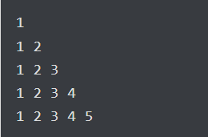

```python
# Number staircase pattern

n = int(input("Enter the number of rows: "))

for i in range(1, n + 1):
    for j in range(1, i + 1):
        print(j, end=" ")
    print()
```

[output not shown]